# Identificacion de patrones, tendencias y visualizacion exploratoria (D_mod 2024-2025)

Edwin Silva Salas

2026-08-03

# Etapa 3 — Identificacion de patrones, tendencias y visualizacion exploratoria (Seccion 5.3.6)

Dataset **$D_{\mathrm{mod}}$**: tabla agregada cuadrante × semana (`data_agrupada_mod.csv`, 2024–2025). Restringido tras el diagnostico de cobertura OMS (Seccion 5.3.5).

Esta seccion integra la identificacion de patrones y la visualizacion exploratoria sobre $D_{\mathrm{mod}}$ (series de tiempo, diagramas de dispersión y mapas tematicos). La actividad de visualizacion exploratoria (antes prevista como seccion independiente) se fusiona aqui para evitar duplicar figuras con el analisis de patrones.

Metodologias aplicadas:

1. **Patrones temporales:** serie semanal territorial, estacionalidad mensual, comparacion 2024 vs 2025 y ACF/PACF.
2. **Patrones espaciales:** ranking de cuadrantes, ubicacion geografica de cuadrantes top, mapa de intensidad y concentracion territorial.
3. **Patrones clima–evento:** correlacion de Spearman entre variables meteorologicas semanales y `n_eventos`.
4. **Segmentacion por actividad:** clasificacion de cuadrantes segun frecuencia e impacto acumulado.
5. **Visualizacion exploratoria:** series, dispersión precipitacion–eventos, mapas tematicos y segmentacion grafica.

```r
library(tidyverse)
library(lubridate)
library(scales)
library(knitr)
env_path <- file.path("..", "..", ".env")
if (file.exists(".env")) {
  readRenviron(".env")
} else if (file.exists(env_path)) {
  readRenviron(env_path)
}

UBICACION_DATA <- Sys.getenv("UBICACION_DATA")
if (UBICACION_DATA == "") {
  stop("UBICACION_DATA no esta definida. Verifica el archivo .env.")
}

path_mod <- file.path(UBICACION_DATA, "data_agrupada_mod.csv")
path_full <- file.path(UBICACION_DATA, "data_agrupada.csv")

if (file.exists(path_mod)) {
  path_agrupada <- path_mod
  aplicar_filtro_anio <- FALSE
} else if (file.exists(path_full)) {
  path_agrupada <- path_full
  aplicar_filtro_anio <- TRUE
  warning("No se encontro data_agrupada_mod.csv; filtrando data_agrupada.csv a 2024-2025.")
} else {
  stop("No se encontro data_agrupada_mod.csv ni data_agrupada.csv.")
}

path_img_tesis <- file.path("..", "my-paper-overleaf", "img")
```

```r
guardar_plot <- function(plot, archivo, width, height) {
  ggsave(
    file.path(UBICACION_DATA, archivo),
    plot = plot,
    width = width,
    height = height,
    dpi = 300,
    bg = "white"
  )
  if (dir.exists(path_img_tesis)) {
    file.copy(
      file.path(UBICACION_DATA, archivo),
      file.path(path_img_tesis, archivo),
      overwrite = TRUE
    )
  }
}
```

```r
message("Leyendo D_mod (cuadrante x semana, 2024-2025)...")
```

```
## Leyendo D_mod (cuadrante x semana, 2024-2025)...
```

```r
d_mod <- read_csv(path_agrupada, show_col_types = FALSE)

if ("semana" %in% names(d_mod) && !inherits(d_mod$semana, "Date")) {
  d_mod <- d_mod %>% mutate(semana = as.Date(semana))
}

d_mod <- if (aplicar_filtro_anio) {
  d_mod %>% filter(year(semana) %in% 2024:2025)
} else {
  d_mod
}

resumen_panel <- tibble(
  metrica = c("Filas", "Cuadrantes", "Semanas", "Total eventos", "Semana min", "Semana max"),
  valor = c(
    nrow(d_mod),
    n_distinct(d_mod$id_cuadrante),
    n_distinct(d_mod$semana),
    sum(d_mod$n_eventos, na.rm = TRUE),
    as.character(min(d_mod$semana)),
    as.character(max(d_mod$semana))
  )
)

kable(resumen_panel, col.names = c("Metrica", "Valor"))
```

| Metrica | Valor |
| --- | --- |
| Filas | 36120 |
| Cuadrantes | 344 |
| Semanas | 105 |
| Total eventos | 33410 |
| Semana min | 2024-01-01 |
| Semana max | 2025-12-29 |

## 1. Patrones temporales

### 1.1 Serie semanal territorial

```r
serie_semanal_mod <- d_mod %>%
  group_by(semana) %>%
  summarise(
    n_eventos_total = sum(n_eventos, na.rm = TRUE),
    usuarios_total = sum(usuarios_afectados, na.rm = TRUE),
    cuadrantes_activos = sum(n_eventos > 0, na.rm = TRUE),
    .groups = "drop"
  ) %>%
  arrange(semana)

summary(serie_semanal_mod$n_eventos_total)
```

```
##    Min. 1st Qu.  Median    Mean 3rd Qu.    Max.
##    43.0   239.0   331.0   318.2   404.0   648.0
```

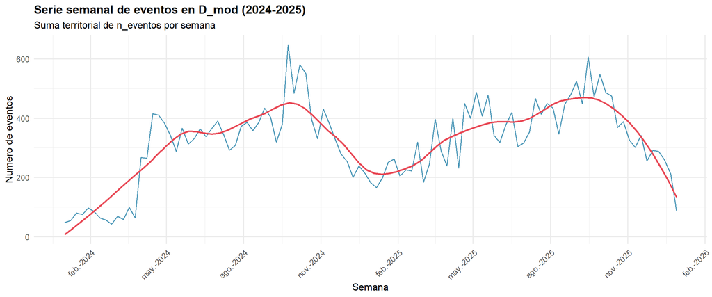

```r
p_serie_mod <- ggplot(serie_semanal_mod, aes(x = semana, y = n_eventos_total)) +
  geom_line(color = "#2E86AB", linewidth = 0.55, alpha = 0.85) +
  geom_smooth(method = "loess", span = 0.35, se = FALSE, color = "#E84855", linewidth = 1) +
  scale_x_date(date_breaks = "3 months", date_labels = "%b-%Y") +
  labs(
    title = "Serie semanal de eventos en D_mod (2024-2025)",
    subtitle = "Suma territorial de n_eventos por semana",
    x = "Semana", y = "Numero de eventos"
  ) +
  theme_minimal(base_size = 12) +
  theme(plot.title = element_text(face = "bold"), axis.text.x = element_text(angle = 45, hjust = 1))

p_serie_mod
```

```r
guardar_plot(p_serie_mod, "serie_semanal_patrones_mod.png", 12, 5)
```

```
## [1] TRUE
```

### 1.2 Estacionalidad mensual y comparacion anual

```r
serie_mes_mod <- serie_semanal_mod %>%
  mutate(
    anio = year(semana),
    mes = factor(
      month(semana),
      levels = 1:12,
      labels = c("Ene", "Feb", "Mar", "Abr", "May", "Jun",
                 "Jul", "Ago", "Sep", "Oct", "Nov", "Dic")
    )
  )

eventos_anio_mod <- d_mod %>%
  mutate(anio = year(semana)) %>%
  group_by(anio) %>%
  summarise(
    n_eventos = sum(n_eventos, na.rm = TRUE),
    n_semanas = n_distinct(semana),
    media_semanal = round(n_eventos / n_semanas, 1),
    .groups = "drop"
  )

kable(eventos_anio_mod, col.names = c("Anio", "Eventos", "Semanas", "Media semanal"))
```

| Anio | Eventos | Semanas | Media semanal |
| --- | --- | --- | --- |
| 2024 | 15211 | 53 | 287 |
| 2025 | 18199 | 52 | 350 |

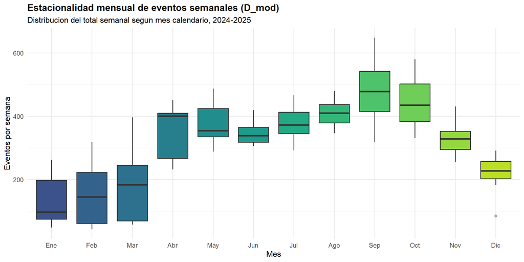

```r
p_estacionalidad_mod <- ggplot(serie_mes_mod, aes(x = mes, y = n_eventos_total, fill = mes)) +
  geom_boxplot(show.legend = FALSE, outlier.alpha = 0.35) +
  scale_fill_viridis_d(option = "D", begin = 0.25, end = 0.9) +
  labs(
    title = "Estacionalidad mensual de eventos semanales (D_mod)",
    subtitle = "Distribucion del total semanal segun mes calendario, 2024-2025",
    x = "Mes", y = "Eventos por semana"
  ) +
  theme_minimal(base_size = 12) +
  theme(plot.title = element_text(face = "bold"))

p_estacionalidad_mod
```

```r
guardar_plot(p_estacionalidad_mod, "estacionalidad_mensual_patrones_mod.png", 11, 5.5)
```

```
## [1] TRUE
```

### 1.3 Autocorrelacion temporal (ACF / PACF)

```r
serie_ts_mod <- serie_semanal_mod$n_eventos_total
max_lag <- min(40, length(serie_ts_mod) - 1)

png(
  file.path(UBICACION_DATA, "acf_serie_patrones_mod.png"),
  width = 11, height = 5, units = "in", res = 300
)
par(mfrow = c(1, 2), mar = c(4, 4, 3, 1))
acf(serie_ts_mod, lag.max = max_lag, main = "ACF — D_mod (semanas)")
pacf(serie_ts_mod, lag.max = max_lag, main = "PACF — D_mod (semanas)")
dev.off()
```

```r
if (dir.exists(path_img_tesis)) {
  file.copy(
    file.path(UBICACION_DATA, "acf_serie_patrones_mod.png"),
    file.path(path_img_tesis, "acf_serie_patrones_mod.png"),
    overwrite = TRUE
  )
}
```

```
## [1] TRUE
```

```r
acf_val <- as.numeric(acf(serie_ts_mod, lag.max = min(12, max_lag), plot = FALSE)$acf)
tibble(
  rezago = 0:min(12, max_lag),
  acf = round(acf_val, 3)
) %>%
  kable(col.names = c("Rezago (semanas)", "ACF"))
```

| Rezago (semanas) | ACF |
| --- | --- |
| 0 | 1.000 |
| 1 | 0.796 |
| 2 | 0.738 |
| 3 | 0.653 |
| 4 | 0.581 |
| 5 | 0.477 |
| 6 | 0.434 |
| 7 | 0.343 |
| 8 | 0.249 |
| 9 | 0.166 |
| 10 | 0.111 |
| 11 | 0.016 |
| 12 | -0.034 |

## 2. Patrones espaciales

### 2.1 Ranking de cuadrantes por actividad

```r
ranking_cuadrantes <- d_mod %>%
  group_by(id_cuadrante, latitud, longitud) %>%
  summarise(
    n_eventos = sum(n_eventos, na.rm = TRUE),
    usuarios = sum(usuarios_afectados, na.rm = TRUE),
    duracion_h = sum(duracion_total, na.rm = TRUE),
    semanas_activas = sum(n_eventos > 0),
    .groups = "drop"
  ) %>%
  arrange(desc(n_eventos))

top_cuadrantes <- ranking_cuadrantes %>% slice_head(n = 15)
kable(top_cuadrantes, digits = 1)
```

| id_cuadrante | latitud | longitud | n_eventos | usuarios | duracion_h | semanas_activas |
| --- | --- | --- | --- | --- | --- | --- |
| 117 | 7.9 | -72.5 | 2224 | 1070799 | 8764.2 | 1 |
| 107 | 7.9 | -72.5 | 779 | 478924 | 4880.9 | 1 |
| 126 | 7.9 | -72.5 | 608 | 250499 | 3259.7 | 1 |
| 85 | 7.7 | -72.7 | 572 | 24059 | 15387.2 | 1 |
| 66 | 7.6 | -72.6 | 549 | 94111 | 7356.2 | 1 |
| 116 | 7.9 | -72.5 | 504 | 200392 | 6562.3 | 1 |
| 203 | 8.3 | -73.5 | 416 | 238318 | 1786.1 | 1 |
| 189 | 8.2 | -73.4 | 404 | 92545 | 2868.8 | 1 |
| 297 | 8.6 | -72.7 | 399 | 51968 | 11026.2 | 1 |
| 86 | 7.7 | -72.6 | 392 | 24823 | 5117.2 | 1 |
| 64 | 7.6 | -72.8 | 389 | 12982 | 14957.7 | 1 |
| 94 | 7.8 | -72.8 | 340 | 25187 | 10087.7 | 1 |
| 75 | 7.7 | -72.6 | 329 | 7606 | 11766.9 | 1 |
| 202 | 8.3 | -73.6 | 329 | 25608 | 2163.0 | 1 |
| 76 | 7.7 | -72.6 | 312 | 16086 | 6449.8 | 1 |

```r
total_eventos <- sum(ranking_cuadrantes$n_eventos)
concentracion_top10 <- ranking_cuadrantes %>%
  slice_head(n = 10) %>%
  summarise(pct = round(100 * sum(n_eventos) / total_eventos, 1))

cat("Eventos en top 10 cuadrantes (%):", concentracion_top10$pct, "\n")
```

```
## Eventos en top 10 cuadrantes (%): 20.5
```

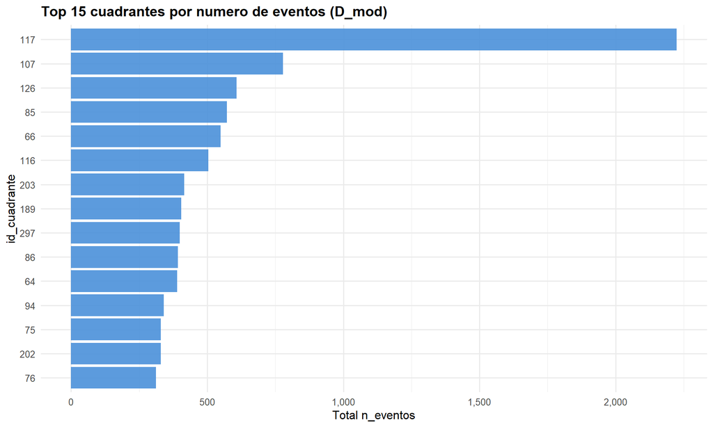

```r
top_plot <- top_cuadrantes %>%
  mutate(id_cuadrante = factor(id_cuadrante, levels = rev(id_cuadrante)))

p_ranking <- ggplot(top_plot, aes(x = n_eventos, y = id_cuadrante)) +
  geom_col(fill = "#4A90D9", alpha = 0.9) +
  scale_x_continuous(labels = comma) +
  labs(
    title = "Top 15 cuadrantes por numero de eventos (D_mod)",
    x = "Total n_eventos", y = "id_cuadrante"
  ) +
  theme_minimal(base_size = 12) +
  theme(plot.title = element_text(face = "bold"))

p_ranking
```

```r
guardar_plot(p_ranking, "ranking_cuadrantes_patrones_mod.png", 10, 6)
```

```
## [1] TRUE
```

### 2.2 Ubicacion geografica de cuadrantes top

La figura siguiente complementa el ranking con la **ubicacion espacial** de los cuadrantes mas activos sobre la malla del area de estudio (Norte de Santander). Los recuadros resaltados corresponden a los primeros cuadrantes *top* del periodo 2024–2025 y muestran concentracion en: (i) el area metropolitana de Cucuta y Villa del Rosario; (ii) un corredor al suroccidente (Salazar, Arboledas, Durania, Chinacota); (iii) la subregion de Tibu; y (iv) los municipios de Ocana y Aguachica.

```r
archivo_ubicacion <- "ubicacion_top_cuadrantes_mod.png"
path_ubicacion_tesis <- file.path(path_img_tesis, archivo_ubicacion)
path_ubicacion_data <- file.path(UBICACION_DATA, archivo_ubicacion)

if (!file.exists(path_ubicacion_tesis)) {
  stop(
    "No se encontro la imagen de ubicacion top cuadrantes: ",
    path_ubicacion_tesis
  )
}

if (!identical(normalizePath(path_ubicacion_data), normalizePath(path_ubicacion_tesis))) {
  file.copy(path_ubicacion_tesis, path_ubicacion_data, overwrite = TRUE)
}
```

```
## [1] TRUE
```

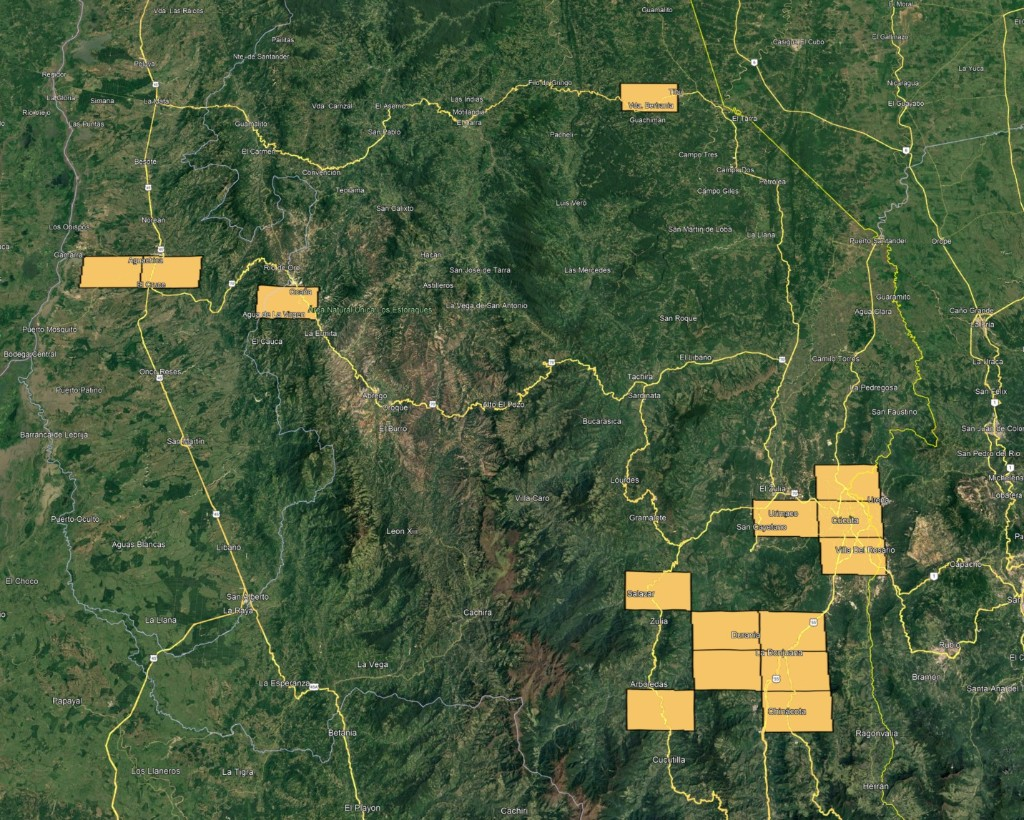

```r
knitr::include_graphics(path_ubicacion_tesis)
```

### 2.3 Mapa de intensidad territorial

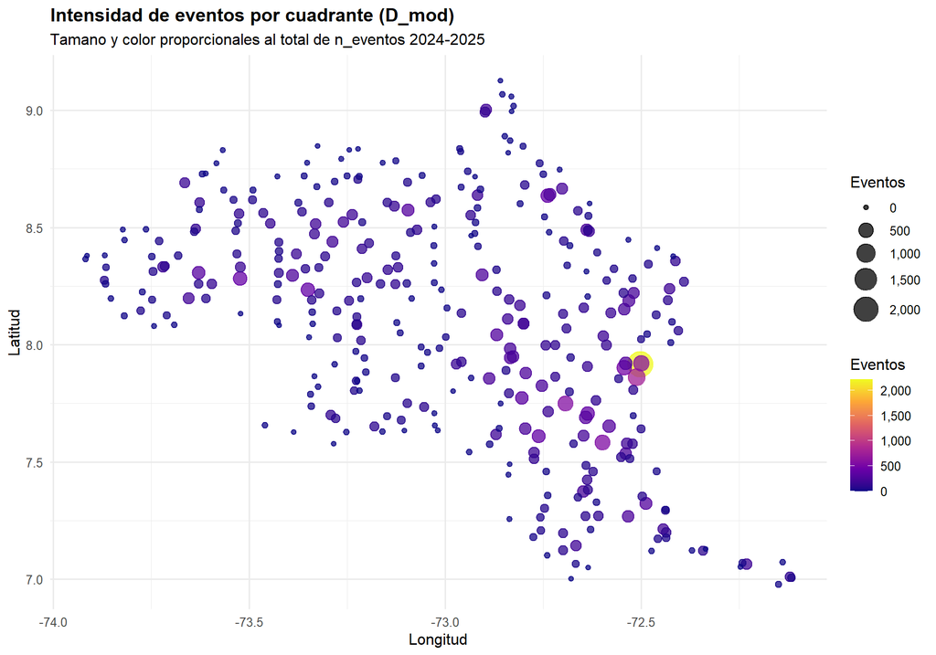

```r
p_mapa <- ggplot(ranking_cuadrantes, aes(x = longitud, y = latitud)) +
  geom_point(aes(size = n_eventos, color = n_eventos), alpha = 0.75) +
  scale_size_continuous(range = c(1.5, 9), labels = comma) +
  scale_color_viridis_c(option = "C", labels = comma) +
  labs(
    title = "Intensidad de eventos por cuadrante (D_mod)",
    subtitle = "Tamano y color proporcionales al total de n_eventos 2024-2025",
    x = "Longitud", y = "Latitud",
    size = "Eventos", color = "Eventos"
  ) +
  theme_minimal(base_size = 12) +
  theme(plot.title = element_text(face = "bold"))

p_mapa
```

```r
guardar_plot(p_mapa, "mapa_intensidad_cuadrantes_patrones_mod.png", 10, 7)
```

```
## [1] TRUE
```

## 3. Patrones clima–evento

```r
vars_clima <- c(
  "temp_media_semana", "temp_max_semana", "temp_min_semana",
  "humedad_media_semana", "viento_medio_semana", "viento_max_semana",
  "precip_total_semana"
)

cor_eventos <- map_dfr(vars_clima, function(v) {
  x <- d_mod[[v]]
  y <- d_mod$n_eventos
  ok <- complete.cases(x, y)
  ct <- suppressWarnings(cor.test(x[ok], y[ok], method = "spearman"))
  tibble(
    variable = v,
    rho = unname(ct$estimate),
    p_value = ct$p.value
  )
}) %>%
  mutate(
    rho = round(rho, 3),
    p_value = signif(p_value, 3),
    significativo = p_value < 0.05
  ) %>%
  arrange(desc(abs(rho)))

kable(cor_eventos, col.names = c("Variable", "Spearman rho", "p-valor", "Significativo"))
```

| Variable | Spearman rho | p-valor | Significativo |
| --- | --- | --- | --- |
| viento_max_semana | 0.139 | 0 | TRUE |
| viento_medio_semana | 0.135 | 0 | TRUE |
| precip_total_semana | 0.065 | 0 | TRUE |
| humedad_media_semana | 0.054 | 0 | TRUE |
| temp_media_semana | -0.047 | 0 | TRUE |
| temp_min_semana | -0.042 | 0 | TRUE |
| temp_max_semana | -0.029 | 0 | TRUE |

[figure not shown]

```r
d_precip <- d_mod %>%
  filter(precip_total_semana <= 200000) %>%
  filter(precip_total_semana > 0 | n_eventos > 0)

p_precip <- ggplot(d_precip, aes(x = precip_total_semana, y = n_eventos)) +
  geom_point(alpha = 0.12, size = 0.9, color = "#2E86AB") +
  geom_smooth(method = "loess", se = TRUE, color = "#E84855", linewidth = 0.9) +
  scale_x_continuous(labels = comma, limits = c(0, 200000)) +
  labs(
    title = "Relacion precipitacion semanal y n_eventos por cuadrante",
    subtitle = "D_mod (2024-2025); suavizado LOESS; precipitacion <= 200.000 mm",
    x = "Precipitacion total semanal (mm)", y = "n_eventos"
  ) +
  theme_minimal(base_size = 12) +
  theme(plot.title = element_text(face = "bold"))

p_precip
```

```r
guardar_plot(p_precip, "dispersion_precip_eventos_patrones_mod.png", 9, 5.5)
```

```
## [1] TRUE
```

## 4. Segmentacion por nivel de actividad

```r
cuadrante_actividad <- ranking_cuadrantes %>%
  mutate(
    nivel = case_when(
      n_eventos == 0 ~ "Sin eventos",
      n_eventos <= quantile(n_eventos[n_eventos > 0], 0.50) ~ "Baja",
      n_eventos <= quantile(n_eventos[n_eventos > 0], 0.85) ~ "Media",
      TRUE ~ "Alta"
    ),
    nivel = factor(nivel, levels = c("Sin eventos", "Baja", "Media", "Alta"))
  )

tabla_segmentacion <- cuadrante_actividad %>%
  count(nivel, name = "n_cuadrantes") %>%
  mutate(pct = round(100 * n_cuadrantes / sum(n_cuadrantes), 1))

kable(tabla_segmentacion, col.names = c("Nivel de actividad", "Cuadrantes", "%"))
```

| Nivel de actividad | Cuadrantes | % |
| --- | --- | --- |
| Sin eventos | 20 | 5.8 |
| Baja | 162 | 47.1 |
| Media | 113 | 32.8 |
| Alta | 49 | 14.2 |

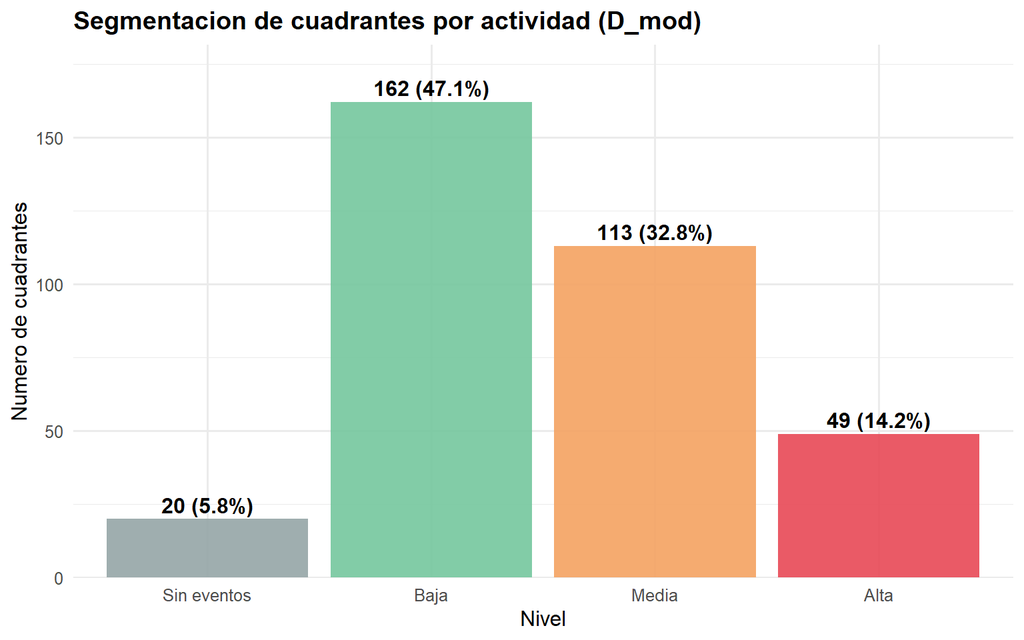

```r
p_segmentacion <- ggplot(tabla_segmentacion, aes(x = nivel, y = n_cuadrantes, fill = nivel)) +
  geom_col(alpha = 0.9, show.legend = FALSE) +
  geom_text(aes(label = paste0(n_cuadrantes, " (", pct, "%)")), vjust = -0.4, fontface = "bold") +
  scale_fill_manual(values = c("#95A5A6", "#74C69D", "#F4A261", "#E84855")) +
  scale_y_continuous(expand = expansion(mult = c(0, 0.12))) +
  labs(
    title = "Segmentacion de cuadrantes por actividad (D_mod)",
    x = "Nivel", y = "Numero de cuadrantes"
  ) +
  theme_minimal(base_size = 12) +
  theme(plot.title = element_text(face = "bold"))

p_segmentacion
```

```r
guardar_plot(p_segmentacion, "segmentacion_cuadrantes_patrones_mod.png", 8, 5)
```

```
## [1] TRUE
```

## 5. Sintesis de hallazgos

```r
hallazgos <- tibble(
  bloque = c(
    "Temporal",
    "Temporal",
    "Espacial",
    "Clima",
    "Segmentacion"
  ),
  hallazgo = c(
    paste0("Media semanal de eventos: ", round(mean(serie_semanal_mod$n_eventos_total), 1)),
    paste0("ACF rezago 1: ", round(acf_val[2], 2)),
    paste0("Top 10 cuadrantes concentran ", concentracion_top10$pct, "% de eventos"),
    paste0(
      "Mayor |rho| clima-evento: ",
      cor_eventos$variable[1], " (rho = ", cor_eventos$rho[1], ")"
    ),
    paste0(
      "Cuadrantes nivel alto: ",
      tabla_segmentacion$n_cuadrantes[tabla_segmentacion$nivel == "Alta"], " (",
      tabla_segmentacion$pct[tabla_segmentacion$nivel == "Alta"], "%)"
    )
  )
)

kable(hallazgos, col.names = c("Bloque", "Hallazgo"))
```

| Bloque | Hallazgo |
| --- | --- |
| Temporal | Media semanal de eventos: 318.2 |
| Temporal | ACF rezago 1: 0.8 |
| Espacial | Top 10 cuadrantes concentran 20.5% de eventos |
| Clima | Mayor \|rho\| clima-evento: viento_max_semana (rho = 0.139) |
| Segmentacion | Cuadrantes nivel alto: 49 (14.2%) |

Los patrones identificados sobre $D_{\mathrm{mod}}$ orientan la Etapa~4: rezagos temporales, variables climaticas con mayor asociacion y estratificacion territorial para el modelado de continuidad del servicio.